# DS Minor: Lab 02 – Centrality measures and community detection Intro

На предыдущем занятии мы поговорили о сетях в целом и посмотрели на свои сети друзей ВК (lab01-networksIntro).

### Меры центральности

Не все вершины в сети однаково важны – какие-то могут быть более влиятельны, какие-то менее. В разных задачах “важность” может пониматься по-разному.

Например, можно считать в сети друзей важнее того из них, у кого больше друзей (“чем больше связей, тем лучше”). Такой показатель называется **степенью (degree)**.

Рассмотрим на небольшом примере социальной сети - сети клуба карате (Zachary carate club).

Загрузим данные из пакета igraphdata (здесь цвет – вручную заданные группы)

```r
library(igraph)
library(igraphdata)
data(karate) # loading nnetwork from package
```

Посчитаем степень узла

```r
degree(karate)
```

```
##    Mr Hi  Actor 2  Actor 3  Actor 4  Actor 5  Actor 6  Actor 7  Actor 8
##       16        9       10        6        3        4        4        4
##  Actor 9 Actor 10 Actor 11 Actor 12 Actor 13 Actor 14 Actor 15 Actor 16
##        5        2        3        1        2        5        2        2
## Actor 17 Actor 18 Actor 19 Actor 20 Actor 21 Actor 22 Actor 23 Actor 24
##        2        2        2        3        2        2        2        5
## Actor 25 Actor 26 Actor 27 Actor 28 Actor 29 Actor 30 Actor 31 Actor 32
##        3        3        2        4        3        4        4        6
## Actor 33   John A
##       12       17
```

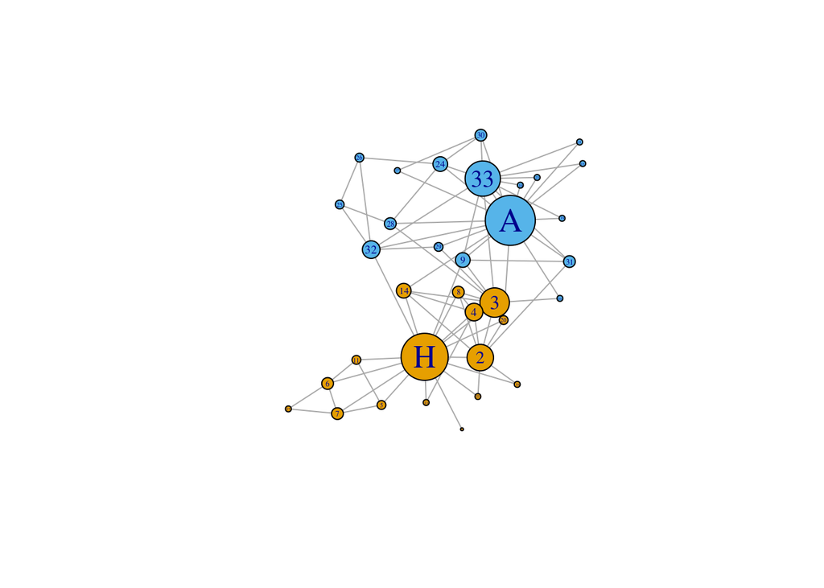

```r
plot(karate, vertex.size = degree(karate)*2,
     vertex.label.cex = degree(karate)/10,
     layout = layout.davidson.harel)
```

Еще одним показателем важности является **центральность по посредничеству, битвинность (betweenness)**. В этом случае важны вершины, которые являются посредниками между группами, находятся на “выгодном” месте.

```r
betweenness(karate)
```

```
##      Mr Hi    Actor 2    Actor 3    Actor 4    Actor 5    Actor 6
## 250.150000  33.800000  36.650000   1.333333   0.500000  15.500000
##    Actor 7    Actor 8    Actor 9   Actor 10   Actor 11   Actor 12
##  15.500000   0.000000  13.100000   7.283333   0.500000   0.000000
##   Actor 13   Actor 14   Actor 15   Actor 16   Actor 17   Actor 18
##   0.000000   1.200000   0.000000   0.000000   0.000000  16.100000
##   Actor 19   Actor 20   Actor 21   Actor 22   Actor 23   Actor 24
##   3.000000 127.066667   0.000000   0.000000   0.000000   1.000000
##   Actor 25   Actor 26   Actor 27   Actor 28   Actor 29   Actor 30
##  33.833333   0.500000   0.000000   6.500000  10.100000   0.000000
##   Actor 31   Actor 32   Actor 33     John A
##   3.000000  66.333333  38.133333 209.500000
```

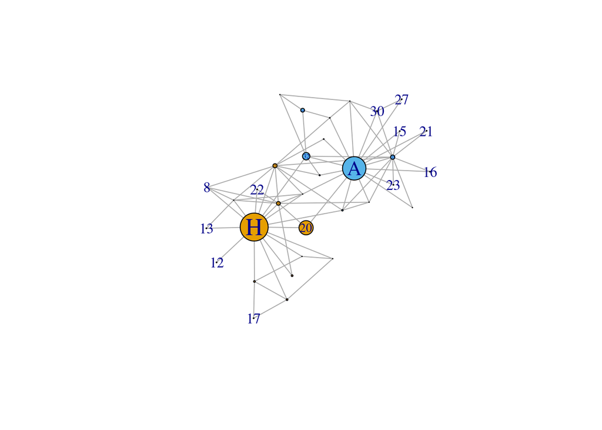

```r
plot(karate, vertex.size = betweenness(karate)/10,
     vertex.label.cex = betweenness(karate)/150,
     layout = layout.davidson.harel)
```

### Выявление сообществ (community detection)

Основная идея выделения сообществ – члены сообщества должны быть больше похожи друг на друга, чем на участников других сообществ (другими словами, число связей между членами одного сообщества должно быть больше, чем число связей между сообществами).

Метод **edge betweenness**: иерархический метод, состоящий в последовательном удалении связей в порядке убывания показателей битвинности ребер (edge betweenness scores), то есть числа кратчайших путей, проходящих по рассматриваемому ребру.

```r
ebcommune <- edge.betweenness.community(karate)
membership(ebcommune) ## assigning nodes to communities
```

```
##    Mr Hi  Actor 2  Actor 3  Actor 4  Actor 5  Actor 6  Actor 7  Actor 8
##        1        1        2        1        3        3        3        1
##  Actor 9 Actor 10 Actor 11 Actor 12 Actor 13 Actor 14 Actor 15 Actor 16
##        4        2        3        1        1        2        4        4
## Actor 17 Actor 18 Actor 19 Actor 20 Actor 21 Actor 22 Actor 23 Actor 24
##        3        1        4        1        4        1        4        5
## Actor 25 Actor 26 Actor 27 Actor 28 Actor 29 Actor 30 Actor 31 Actor 32
##        5        5        6        5        2        6        4        4
## Actor 33   John A
##        4        4
```

```r
modularity(ebcommune)
```

```
## [1] 0.345299
```

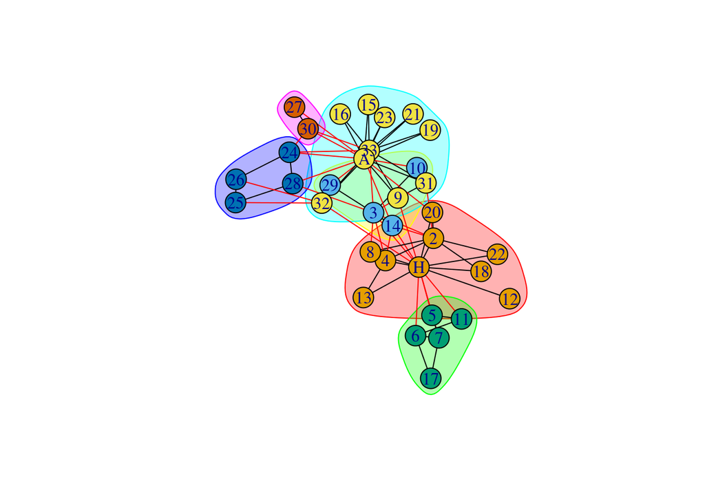

```r
plot(ebcommune, karate)
```

Сколько групп получилось?

**Ваша очередь:**

Исследуйте свою сеть. Какие выводы вы можете сделать?